# Using STRUDEL to create concept-feature norms for many languages

Erin M. Buchanan, Jonathan Korn, Mark Newman

# Large Datasets Answer Questions

- Research in computational linguistics is improved by large copora or datasets
- Data can be used as data for hypothesis testing or stimuli selection for experimental research
- Open Subtitles Corpus (http://opus.nlpl.eu/OpenSubtitles-v2018.php) provides linguistic data for 50+ languages
- Previous research with the subtitle corpora have shown their usefulness (New et al., 2007; Brysbaert & New, 2009; Keuleers et al., 2010; Cuetos et al., 2012; Van Heuven et al., 2014; Mandera et al., 2015; and more)
- The corpora are freely available to download for use in linguistic projects

# Semantic Feature Production Norms

- The property listing task is used to create concept-feature norms
- Participants are asked to list the properties of listed concepts
  - Dog <is an animal>, <barks>, <has a tail>
- The time and effort to create and clean comprehensive concept-features norms is lengthy
- However, concept-feature norms are useful, especially for measures of semantic similarity.

# STRUDEL

- Baroni, Murphy, Barbu, & Poesio (2010)
- Structured Dimension Extraction and Labeling
- Proposed model that provides a structured way to extract concept-feature norms from large corpora
- Compared to the McRae norms, STRUDEL provides promising results:
  - Book <reader>, <author>, <library>, <chapter>

# Limitations of STRUDEL as Presented

- One key limitation to STRUDEL is the embedded rules of concept-property extraction that are focused on the English Language
- Extrapolating this structure to other langauges may not provide similar results, even as other languages have similar sentence structure
- Additionally, the code is difficult to navigate requiring Perl and other installed corpus software

# Basic Concept of STRUDEL

- The core idea of STRUDEL is dependency parsing
- Dependency parsers are avaliable in many languages
- `udpipe` provides an excellent package

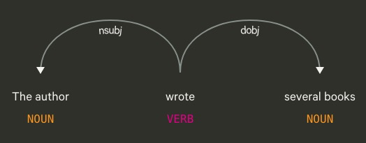

# Processing Steps

- Import the tokenized text version of the Open Subtitle Corpus,
- For each sentence, use `udpipe` to process for part of speech tags, lemmas, and dependency parsing
- Extract all nouns, verbs, and adjectives
- Extract dependency relations: `"nsubj", "nmod", "obj", "iobj", "amod", "obl"`
- Provide frequencies of the combinations present in the corpus

# Example

```
##   token_id   token   lemma upos dep_rel head_token_id
## 1        1     The     the  DET     det             2
## 2        2  author  author NOUN   nsubj             3
## 3        3   wrote   write VERB    root             0
## 4        4 several several  ADJ    amod             5
## 5        5   books    book NOUN     obj             3
```

# English Results

- 27,392,305 combinations of nouns, verbs, and adjectives across the subset of dependency relations
- 308,646,868 instances counted
- 1 to 391,437 frequency (last-night)
- Examine results for a few words: house, conference, dry, night

# English Results

- Questions:
  - Does the dependency make more “sense” forward or backward?
  - What should the minimum frequency be for usage?

# English Results

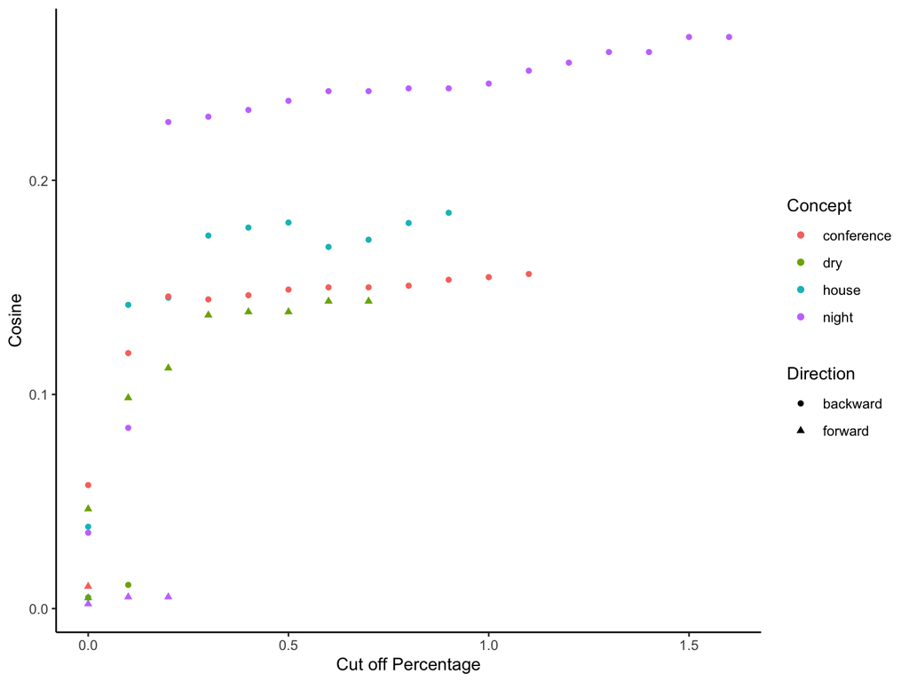

# PSA 007 SPAM-L

- Outcomes:
  - Create concept-feature norms in each language possible (23 completed!)
  - Provide examples and suggested guidelines for usage
- These outcomes will be used for a larger set of projects on semantic priming
- Learn more: https://psysciacc.org/psacon2020-videos/
- Join us! Email buchananlab@gmail.com

[figure not shown]

# Questions

- Thanks for listening!
- Interested in the code? Check it out: https://github.com/SemanticPriming/subs2strudel
- Click on Releases to see the data!